# 4/14/20 Check-In

Evelyn Cai

4/7/2020

The first set of graphs correspond to the AMCE plot in the paper that compares the AMCEs of variables for respondents from all four treatment groups. The second set of six plots compare different treatment groups with each other.

Ordering of various levels on the y axis is important according to Leeper *et al.* (2019). It matters how they’re displayed so that they do not distort average treatment effect size, hence the specification the level_order is “descending”.

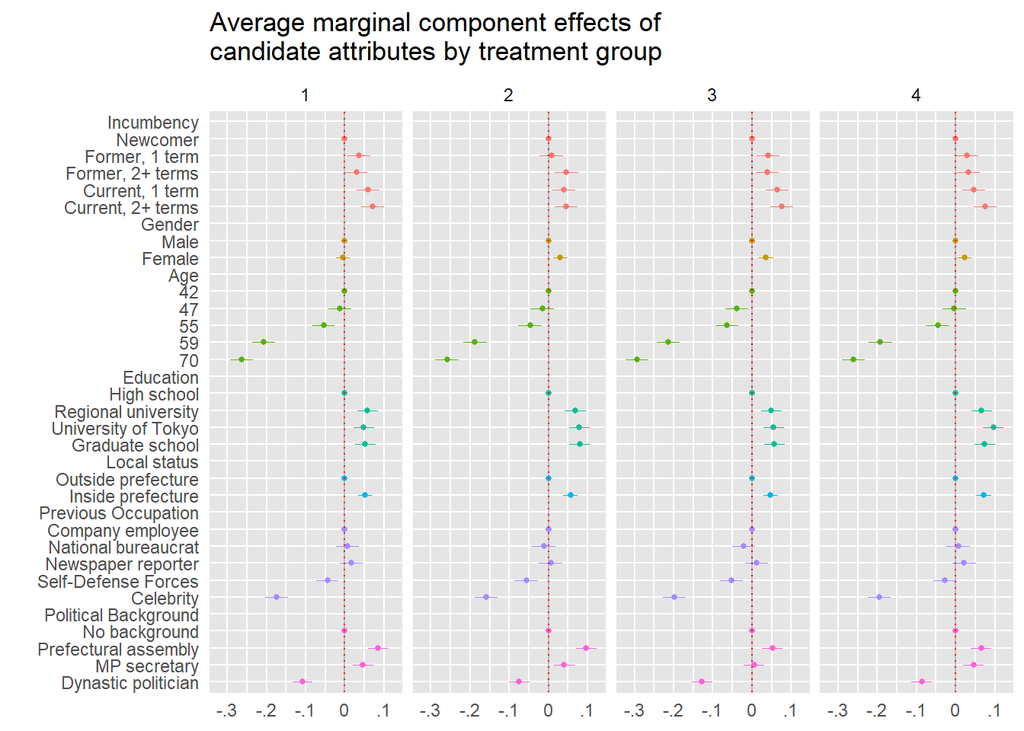

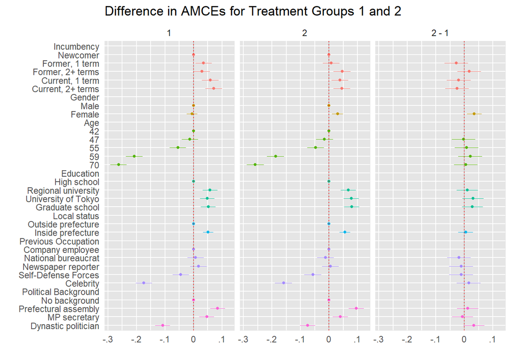

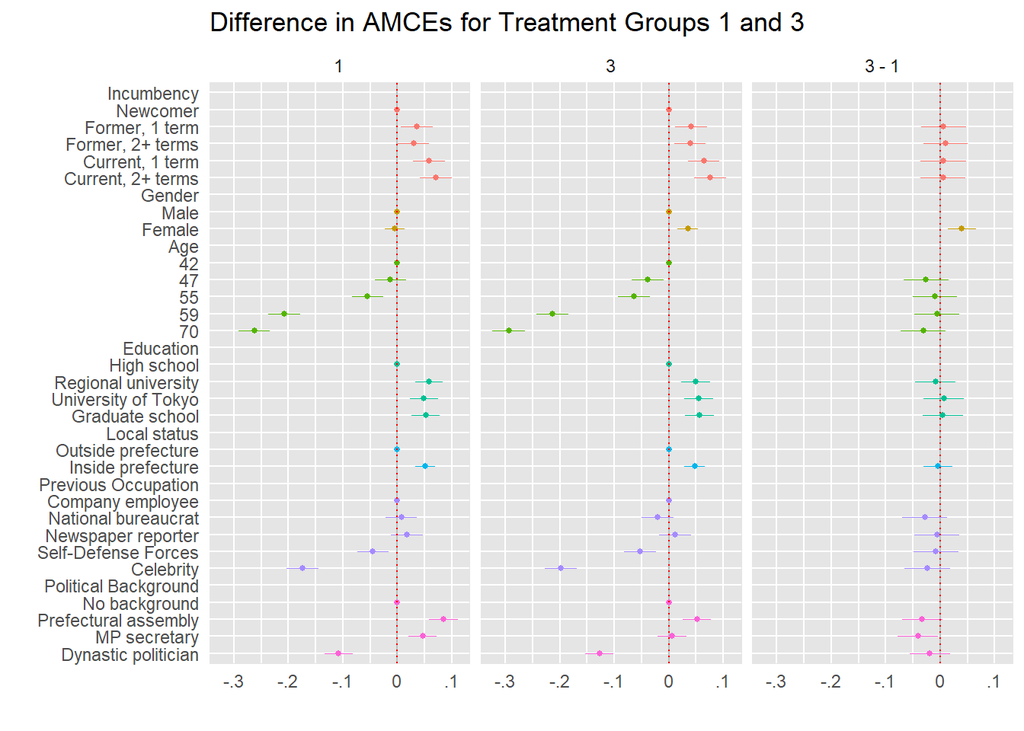

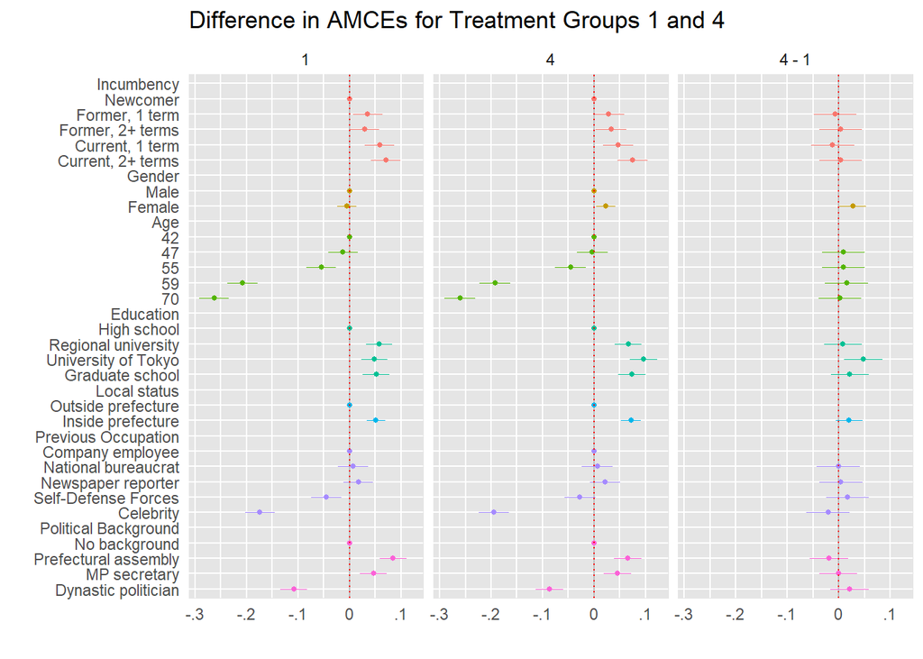

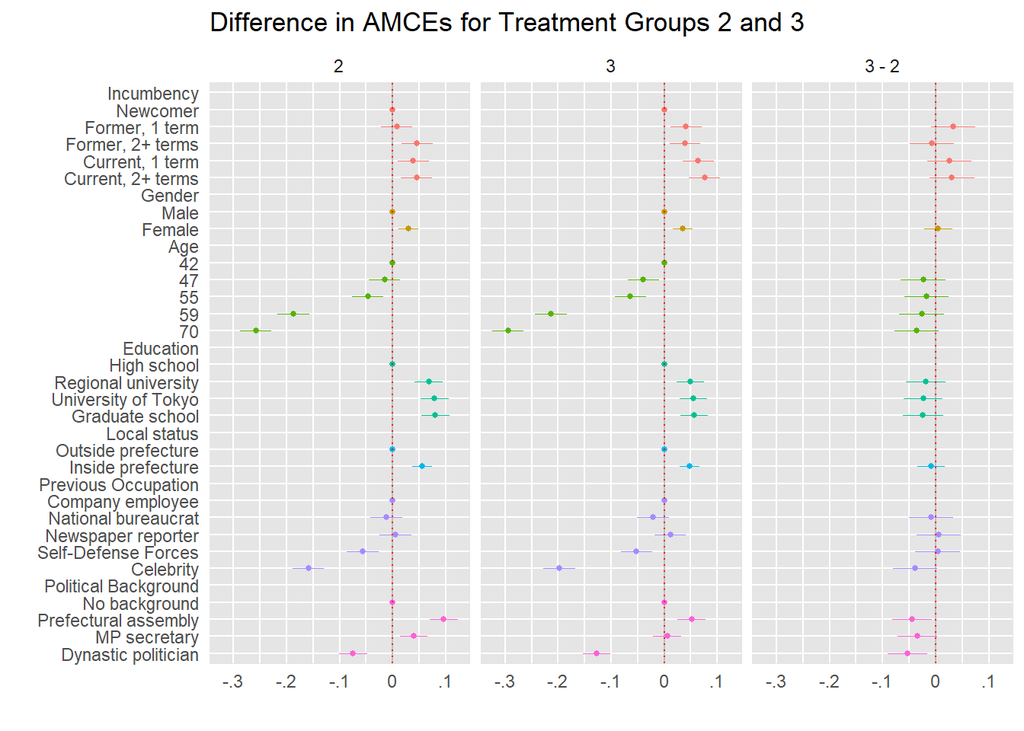

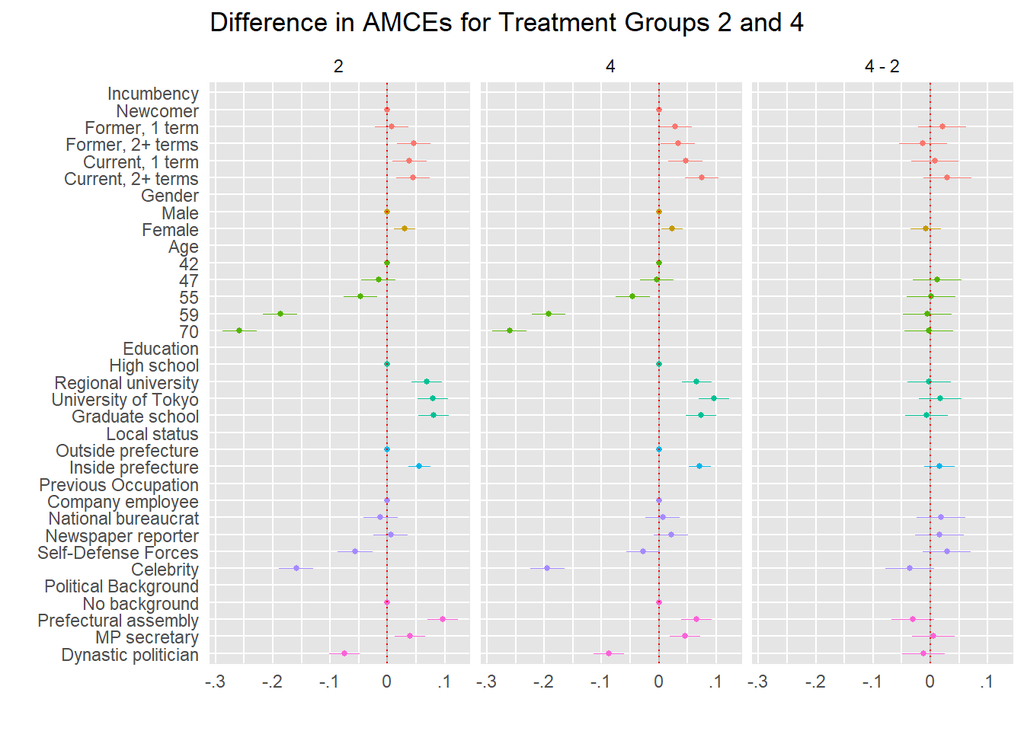

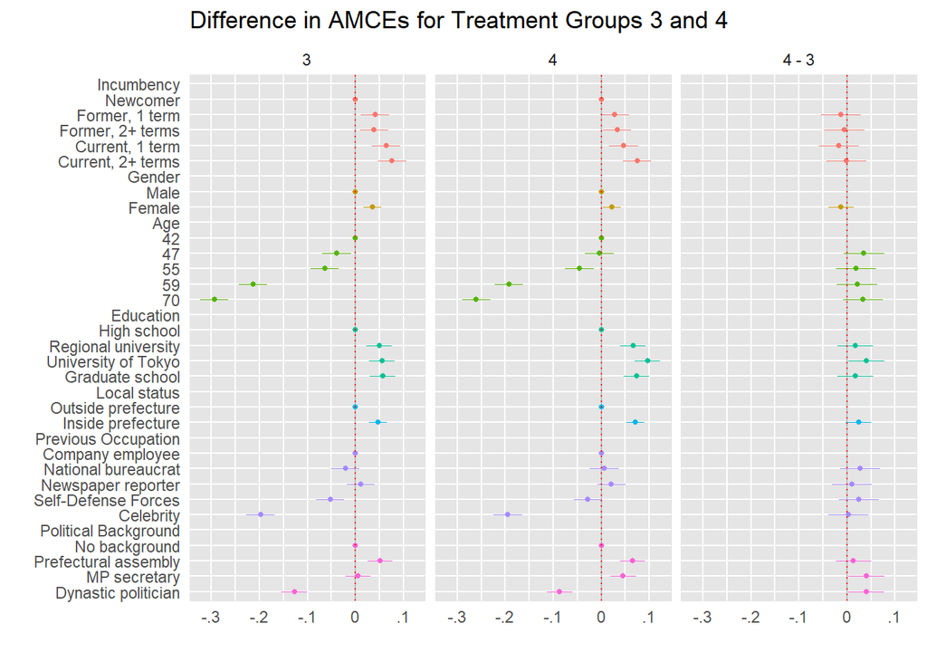

## Marginal Means

According to Leeper *et al.* (2019), “AMCEs infully randomized designs are simply dierences between marginal means at each feature level and the marginal mean in the reference category, ignoring other features.” A flaw with interpreting “differences in conditional AMCEs as differences in underlying preferences” exists because of how the subgroups that are being compared are chosen, and whether there are any meaningful *absolute* differences. Finding the marginal means, then, can be done using the `cregg` package.

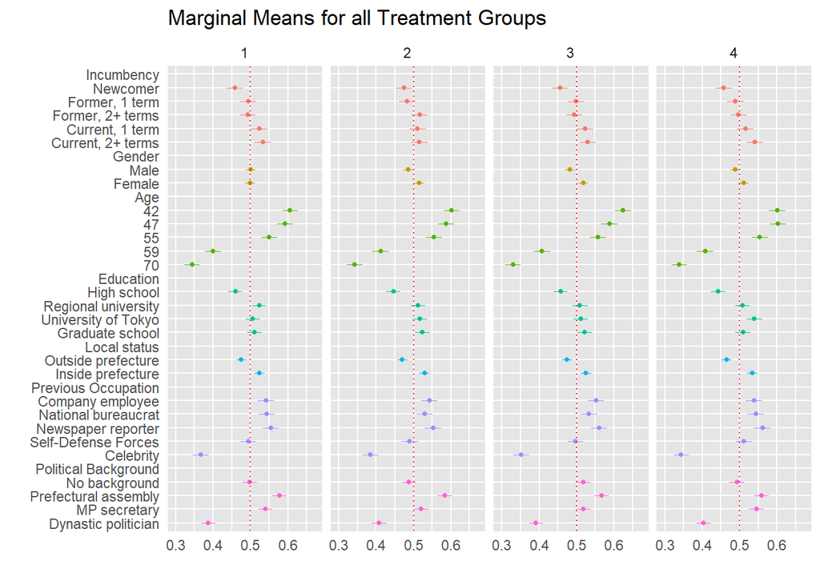

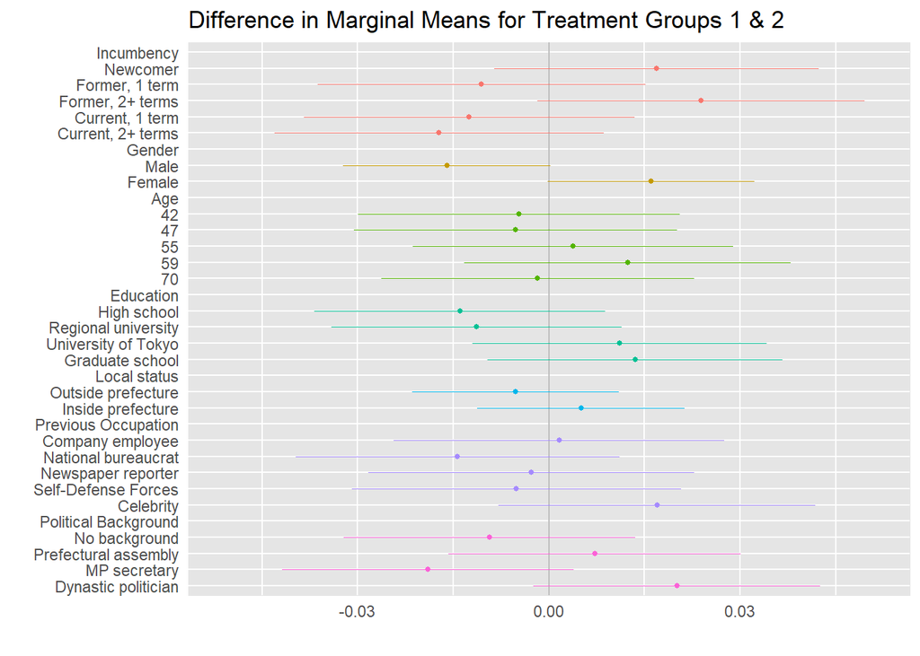

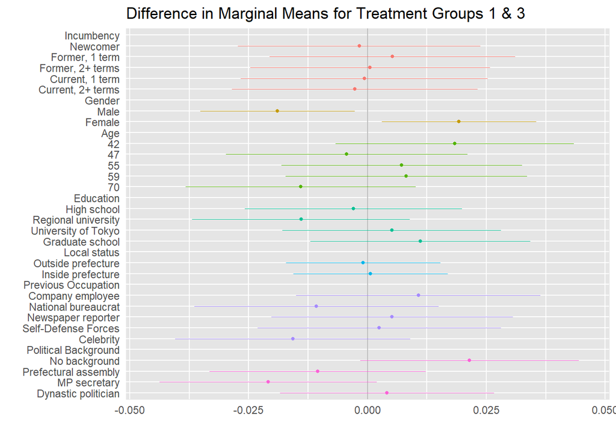

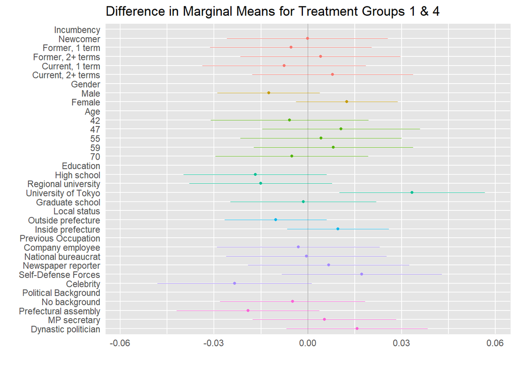

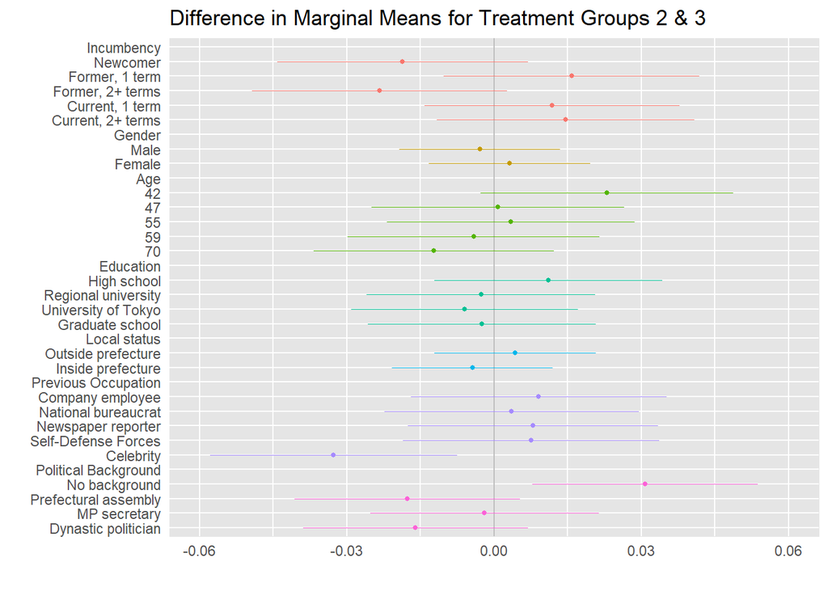

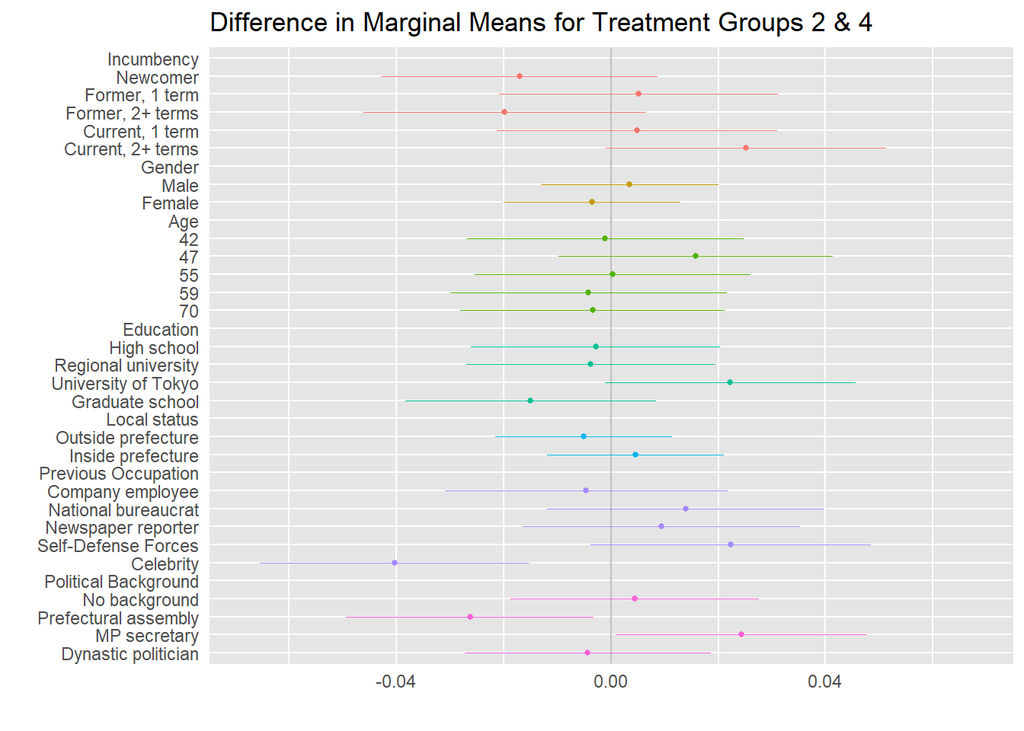

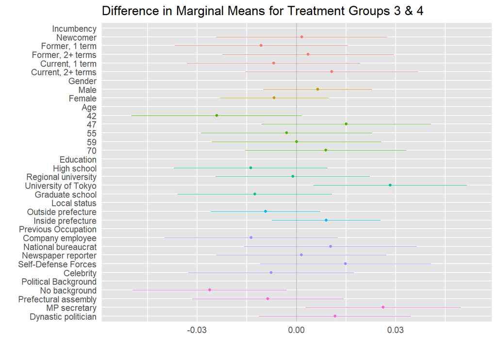